# Practical Machine Learning

# Introduction

The datasets used in this project are from http://groupware.les.inf.puc-rio.br/har website. This data contains the measurement of excercise activity of the participants. Different measurements from Arm,Forearm,Belt and Dumbell sensors were used to record this. The goal of this project is to take the data given in the training dataset , build a model to predict the classe variable and use it to finally predict classe variable in the testing dataset. training dataset - https://d396qusza40orc.cloudfront.net/predmachlearn/pml-training.csv testing dataset - https://d396qusza40orc.cloudfront.net/predmachlearn/pml-testing.csv Outcome variable classe tells whether the participant correctly performed the excercise as specified (Classification A) or did somethings wrong (Classifications B,C,D,E)

# Data Processing

Downloading the training and testing files and loading data

```r
download.file(
        "https://d396qusza40orc.cloudfront.net/predmachlearn/pml-training.csv",
        destfile = "WtLiftingExcerciseTraining.csv", method = "curl")
download.file(
        "https://d396qusza40orc.cloudfront.net/predmachlearn/pml-testing.csv",
        destfile = "WtLiftingExcerciseTesting.csv", method = "curl")

actualTrainingData <- read.csv("WtLiftingExcerciseTraining.csv",header = TRUE,
                               sep=",",na.strings=c("NA","","#DIV/0!"),
                               stringsAsFactors = FALSE)

testing <-read.csv("WtLiftingExcerciseTesting.csv",,header = TRUE,sep=",",
                   na.strings=c("NA","","#DIV/0!"),stringsAsFactors = FALSE)
```

```r
dim(actualTrainingData)
```

```
## [1] 19622   160
```

```r
dim(testing)
```

```
## [1]  20 160
```

```r
str(actualTrainingData)
```

```
## 'data.frame':    19622 obs. of  160 variables:
##  $ X                       : int  1 2 3 4 5 6 7 8 9 10 ...
##  $ user_name               : chr  "carlitos" "carlitos" "carlitos" "carlitos" ...
##  $ raw_timestamp_part_1    : int  1323084231 1323084231 1323084231 1323084232 1323084232 1323084232 1323084232 1323084232 1323084232 1323084232 ...
##  $ raw_timestamp_part_2    : int  788290 808298 820366 120339 196328 304277 368296 440390 484323 484434 ...
##  $ cvtd_timestamp          : chr  "05/12/2011 11:23" "05/12/2011 11:23" "05/12/2011 11:23" "05/12/2011 11:23" ...
##  $ new_window              : chr  "no" "no" "no" "no" ...
##  $ num_window              : int  11 11 11 12 12 12 12 12 12 12 ...
##  $ roll_belt               : num  1.41 1.41 1.42 1.48 1.48 1.45 1.42 1.42 1.43 1.45 ...
##  $ pitch_belt              : num  8.07 8.07 8.07 8.05 8.07 8.06 8.09 8.13 8.16 8.17 ...
##  $ yaw_belt                : num  -94.4 -94.4 -94.4 -94.4 -94.4 -94.4 -94.4 -94.4 -94.4 -94.4 ...
##  $ total_accel_belt        : int  3 3 3 3 3 3 3 3 3 3 ...
##  $ kurtosis_roll_belt      : num  NA NA NA NA NA NA NA NA NA NA ...
##  $ kurtosis_picth_belt     : num  NA NA NA NA NA NA NA NA NA NA ...
##  $ kurtosis_yaw_belt       : logi  NA NA NA NA NA NA ...
```

[output cut: 86 more lines]

Selecting interested columns and ignoring the statiscal computed variables such as avg , var , stddev etc

```r
trainingInterestedCols <- actualTrainingData[, -grep('(X|raw_timestamp_part_1|raw_timestamp_part_2|cvtd_timestamp|^avg|^var|^stddev|^min|^max|^amplitude|^kurtosis|^skewness)', colnames(actualTrainingData))]
```

Converting all interested Character variables to factor variables before training the model

```r
trainingInterestedCols$user_name <- as.factor(trainingInterestedCols$user_name)
testing$user_name <- as.factor(testing$user_name)
trainingInterestedCols$classe <- as.factor(trainingInterestedCols$classe)
```

using Caret Package , Splitting the training data into training and validation datasets. A 70/30 split is used for this. Validation dataset is set aside to check the model accuracy and estimate out of sample error etc.

```r
inTrain <- createDataPartition(y=trainingInterestedCols$classe,p=0.7,list = FALSE)
training <- trainingInterestedCols[inTrain,]
validation <- trainingInterestedCols[-inTrain,]
```

removing columns that has all NA values

```r
trainingNonNA <- training[ , !apply( training , 2 , function(x) all(is.na(x)) )]
```

removing non zero var variables (i.e here new_window)

```r
training <- trainingNonNA[, -nearZeroVar(trainingNonNA)]
```

# Modeling

Trained the model using the Caret package and also utilized the parallel processing capabilities of doMC package To find the optimal model and for cross validatiion,used cv method with 5 folds.

```r
registerDoMC(cores = 24)
modelFit <- train(classe ~ .,
                          data = training,
                          method = "rf",
                          trControl = trainControl(method = "cv",
                                                   number = 5))
modelFit
```

```
## Random Forest
##
## 13737 samples
##    54 predictor
##     5 classes: 'A', 'B', 'C', 'D', 'E'
##
## No pre-processing
## Resampling: Cross-Validated (5 fold)
##
## Summary of sample sizes: 10990, 10990, 10990, 10989, 10989
##
## Resampling results across tuning parameters:
##
##   mtry  Accuracy   Kappa      Accuracy SD  Kappa SD
##    2    0.9937394  0.9920804  0.001916427  0.002424681
##   30    0.9973793  0.9966852  0.001073754  0.001358207
##   58    0.9952682  0.9940145  0.001287128  0.001628660
##
## Accuracy was used to select the optimal model using  the largest value.
## The final value used for the model was mtry = 30.
```

```r
summary(modelFit)
```

```
##                 Length Class      Mode
## call                4  -none-     call
## type                1  -none-     character
## predicted       13737  factor     numeric
## err.rate         3000  -none-     numeric
## confusion          30  -none-     numeric
## votes           68685  matrix     numeric
## oob.times       13737  -none-     numeric
## classes             5  -none-     character
## importance         58  -none-     numeric
## importanceSD        0  -none-     NULL
## localImportance     0  -none-     NULL
## proximity           0  -none-     NULL
## ntree               1  -none-     numeric
## mtry                1  -none-     numeric
## forest             14  -none-     list
## y               13737  factor     numeric
## test                0  -none-     NULL
## inbag               0  -none-     NULL
## xNames             58  -none-     character
## problemType         1  -none-     character
## tuneValue           1  data.frame list
## obsLevels           5  -none-     character
```

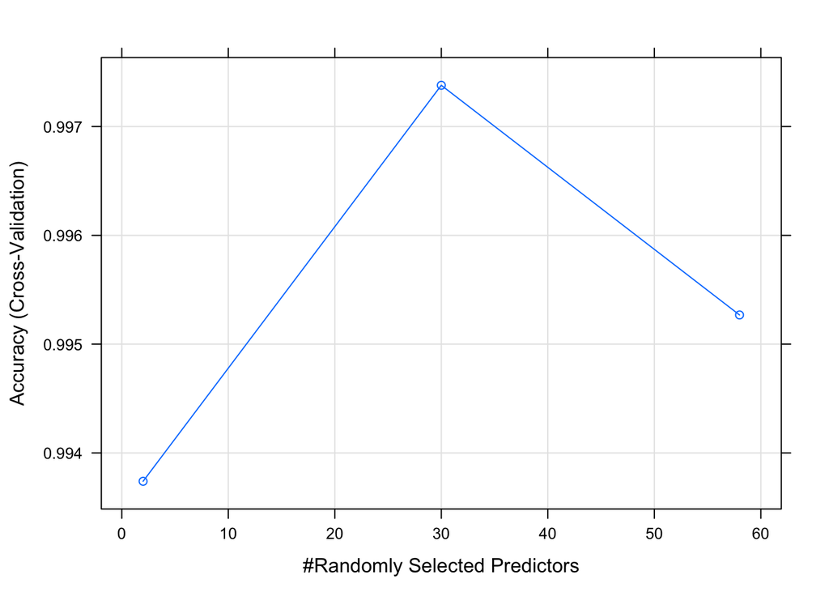

```r
plot(modelFit)
```

# Prediction and Analysis

Applying the model to validation dataset to check accuracy or fine tune model if necessary.

```r
validationPred <- predict(modelFit,validation)
cm<-confusionMatrix(validationPred,validation$classe)
cm
```

```
## Confusion Matrix and Statistics
##
##           Reference
## Prediction    A    B    C    D    E
##          A 1673    3    0    0    0
##          B    0 1136    2    0    0
##          C    0    0 1024    2    0
##          D    0    0    0  962    0
##          E    1    0    0    0 1082
##
## Overall Statistics
##
##                Accuracy : 0.9986
##                  95% CI : (0.9973, 0.9994)
##     No Information Rate : 0.2845
##     P-Value [Acc > NIR] : < 2.2e-16
##
##                   Kappa : 0.9983
##  Mcnemar's Test P-Value : NA
##
## Statistics by Class:
##
##                      Class: A Class: B Class: C Class: D Class: E
## Sensitivity            0.9994   0.9974   0.9981   0.9979   1.0000
## Specificity            0.9993   0.9996   0.9996   1.0000   0.9998
## Pos Pred Value         0.9982   0.9982   0.9981   1.0000   0.9991
## Neg Pred Value         0.9998   0.9994   0.9996   0.9996   1.0000
## Prevalence             0.2845   0.1935   0.1743   0.1638   0.1839
## Detection Rate         0.2843   0.1930   0.1740   0.1635   0.1839
## Detection Prevalence   0.2848   0.1934   0.1743   0.1635   0.1840
## Balanced Accuracy      0.9993   0.9985   0.9988   0.9990   0.9999
```

Based on this we can see that Accuracy is 0.9986406 (>99%) and we expect the out of sample error to be 1 - Accuracy = 0.0013594

Finally applied the model to testing dataset to predict the classe variable.

```r
testingPred <- predict(modelFit,testing)
testingPred
```

```
##  [1] B A B A A E D B A A B C B A E E A B B B
## Levels: A B C D E
```

Writing the final prediction results to output files

```r
pml_write_files = function(x){
  n = length(x)
  for(i in 1:n){
    filename = paste0("problem_id_",i,".txt")
    write.table(x[i],file=filename,quote=FALSE,row.names=FALSE,col.names=FALSE)
  }
}
pml_write_files(testingPred)
```